# Introduction to R

Author

Affiliation

Undergrad Hernandes Peres

[Biometrics Lab.](https://biometria.ufv.br/)

### 1. Objects in R

R is an object-oriented language. Object-oriented programming revolves around objects (data structures) and methods (functions that operate on those objects). In R, this allows you to write functions like `print()` or `summary()` that behave differently depending on the type of object you pass in.

```r
x <- 10
x
```

```
[1] 10
```

```r
x = 10
x
```

```
[1] 10
```

```r
x <- sqrt(2)  # Store the square root of 2 in x.
x
```

```
[1] 1.414214
```

```r
y <- sqrt(5)  # Store the square root of 5 in y.
y
```

```
[1] 2.236068
```

```r
y + x  # Sum of x and y.
```

```
[1] 3.650282
```

### 2. Arithmetic Operations

R can be used for simple arithmetic expressions:

```r
1 + 2 + 3   # Addition
```

```
[1] 6
```

```r
2 + 3 * 4   # Multiplication takes precedence
```

```
[1] 14
```

```r
3 / 2 + 1   # Division precedes addition
```

```
[1] 2.5
```

```r
4 * 3^3     # Power operation
```

```
[1] 108
```

### 3. Common Mathematical Functions

```r
sqrt(2)      # Square root
```

```
[1] 1.414214
```

```r
27^(1/3)     # Cube root
```

```
[1] 3
```

```r
64^(1/4)     # Fourth root
```

```
[1] 2.828427
```

```r
sin(pi)      # Sine of pi (should be close to zero)
```

```
[1] 1.224606e-16
```

Some common mathematical functions in R:

- `sqrt()`: Square root
- `abs()`: Absolute value
- `sin(), cos(), tan()`: Trigonometric functions
- `asin(), acos(), atan()`: Inverse trigonometric functions
- `sinh(), cosh(), tanh()`: Hyperbolic functions
- `asinh(), acosh(), atanh()`: Inverse hyperbolic functions
- `exp(), log()`: Exponential and natural logarithm

```r
log(5)    # Natural logarithm (ln)
```

```
[1] 1.609438
```

```r
log10(5)  # Logarithm base 10
```

```
[1] 0.69897
```

```r
log2(5)   # Logarithm base 2
```

```
[1] 2.321928
```

```r
exp(1.61) # Exponential function
```

```
[1] 5.002811
```

### 4. Vectors

```r
x1 <- 10
x1
```

```
[1] 10
```

```r
x2 <- c(1, 3, 6)
x2
```

```
[1] 1 3 6
```

```r
x2[1]         # First element
```

```
[1] 1
```

```r
x2[2]         # Second element
```

```
[1] 3
```

```r
length(x2)    # Length of vector
```

```
[1] 3
```

```r
is.vector(x2)
```

```
[1] TRUE
```

```r
is.matrix(x2)
```

```
[1] FALSE
```

```r
is.numeric(x2)
```

```
[1] TRUE
```

```r
is.character(x2)
```

```
[1] FALSE
```

### 5. Creating Sequences

```r
x3 <- 1:10                 # Sequence from 1 to 10
x3
```

```
 [1]  1  2  3  4  5  6  7  8  9 10
```

```r
x4 <- seq(0, 1, by = 0.1)  # Sequence from 0 to 1 with step 0.1
x4
```

```
 [1] 0.0 0.1 0.2 0.3 0.4 0.5 0.6 0.7 0.8 0.9 1.0
```

```r
x4[x4 > 0.5]               # Filter values greater than 0.5
```

```
[1] 0.6 0.7 0.8 0.9 1.0
```

```r
x4[x4 >= 0.5]              # Filter values greater than or equal to 0.5
```

```
[1] 0.5 0.6 0.7 0.8 0.9 1.0
```

```r
x4 <= 0.5                  # Logical test
```

```
 [1]  TRUE  TRUE  TRUE  TRUE  TRUE  TRUE FALSE FALSE FALSE FALSE FALSE
```

### 6. Replicating Values

```r
x5 <- seq(0, 1, length.out = 11)
x5
```

```
 [1] 0.0 0.1 0.2 0.3 0.4 0.5 0.6 0.7 0.8 0.9 1.0
```

```r
x6 <- rep(1, 5)              # Repeat 1 five times
x6
```

```
[1] 1 1 1 1 1
```

```r
x7 <- rep(c(1, 2), c(3, 5))  # Repeat 1 three times and 2 five times
x7
```

```
[1] 1 1 1 2 2 2 2 2
```

```r
x8 <- rep(1:3, each = 5)
x8
```

```
 [1] 1 1 1 1 1 2 2 2 2 2 3 3 3 3 3
```

```r
x9 <- rep(2:5, each = 5)
x9
```

```
 [1] 2 2 2 2 2 3 3 3 3 3 4 4 4 4 4 5 5 5 5 5
```

### 7. Random Numbers

In statistics, most simulation methods need to be reproducible, even though they involve simulated data.

Then to achieve it, we can use the function `set.seed()`.

```r
set.seed(123)

x10 <- rnorm(10, mean = 70, sd = 10)
x10
```

```
 [1] 64.39524 67.69823 85.58708 70.70508 71.29288 87.15065 74.60916 57.34939
 [9] 63.13147 65.54338
```

```r
sum(x10)      # Sum
```

```
[1] 707.4626
```

```r
mean(x10)     # Mean
```

```
[1] 70.74626
```

```r
var(x10)      # Variance
```

```
[1] 90.9704
```

```r
sd(x10)       # Standard deviation
```

```
[1] 9.537841
```

```r
min(x10)      # Minimum value
```

```
[1] 57.34939
```

```r
max(x10)      # Maximum value
```

```
[1] 87.15065
```

The `summary()` function is one of the most commonly used functions in R, due to its usability.

```r
summary(x10)  # Summary statistics
```

```
   Min. 1st Qu.  Median    Mean 3rd Qu.    Max.
  57.35   64.68   69.20   70.75   73.78   87.15
```

```r
summary(1:10)
```

```
   Min. 1st Qu.  Median    Mean 3rd Qu.    Max.
   1.00    3.25    5.50    5.50    7.75   10.00
```

### 8. Data Frames

Dataframes are data displayed in a table format

Columns can be `character`, `numeric`, `logical` and/or `factor`.

Each column should have the same type of data.

```r
d1 <- data.frame(X = 1:10,
                 Y = c(51, 54, 61, 67, 68, 75, 77, 75, 80, 82))
d1
```

```
    X  Y
1   1 51
2   2 54
3   3 61
4   4 67
5   5 68
6   6 75
7   7 77
8   8 75
9   9 80
10 10 82
```

```r
summary(d1)
```

```
       X               Y
 Min.   : 1.00   Min.   :51.0
 1st Qu.: 3.25   1st Qu.:62.5
 Median : 5.50   Median :71.5
 Mean   : 5.50   Mean   :69.0
 3rd Qu.: 7.75   3rd Qu.:76.5
 Max.   :10.00   Max.   :82.0
```

Using the `summary()` function we can summarize the data from the dataframe.

```r
names(d1)
```

```
[1] "X" "Y"
```

```r
d1$X  # Column X
```

```
 [1]  1  2  3  4  5  6  7  8  9 10
```

```r
d1$Y  # Column Y
```

```
 [1] 51 54 61 67 68 75 77 75 80 82
```

We can use `$` (dollar sign) to acess a column by its name

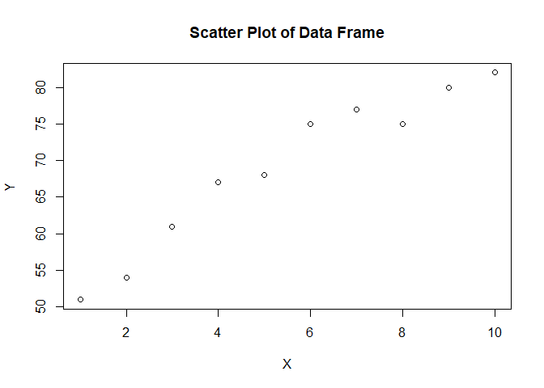

```r
plot(d1)  # Scatter plot
title("Scatter Plot of Data Frame")
```

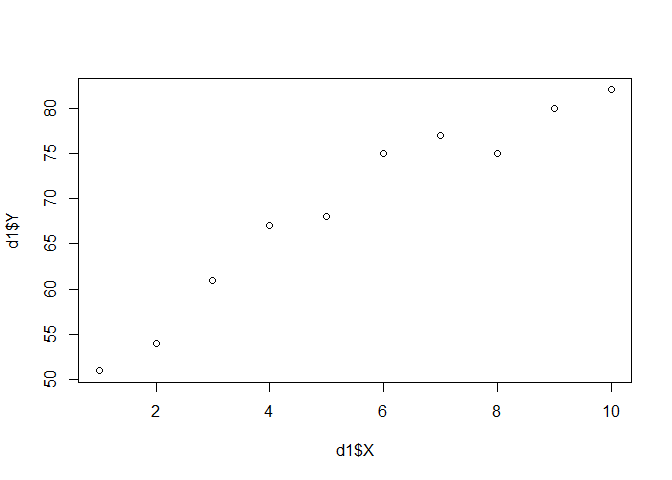

```r
plot(d1$X, d1$Y)  # X vs Y
```

### 9. Creating Data

$$\begin{array}{|c|c|c|c|c|}
\hline
\textbf{Rep} & \textbf{A} & \textbf{B} & \textbf{C} & \textbf{D} \\
\hline
1 & 25 & 31 & 22 & 33 \\
2 & 26 & 25 & 26 & 29 \\
3 & 20 & 28 & 28 & 31 \\
4 & 23 & 27 & 25 & 34 \\
5 & 21 & 24 & 29 & 28 \\
\hline
\end{array}$$

```r
treatments <- rep(c("A", "B", "C", "D"), each = 5)

replicates <- rep(1:5, times = 4)

production <- c(25, 26, 20, 23, 21,
                31, 25, 28, 27, 24,
                22, 26, 28, 25, 29,
                33, 29, 31, 34, 28)

data <- data.frame(treatments, replicates, production)
```

### 10. Reading Data

External data can be read from `.txt` files (plain text) or `.csv` files (comma-separated values), using respectively `read.txt()` and `read.csv()` functions.

Ensure that the file `"data_1.csv"` is present in the working directory before attempting to load it.

```r
data <- read.csv("data_1.csv", header = TRUE)
head(data)
```

```
  treatments replicates production
1          A          1         25
2          A          2         26
3          A          3         20
4          A          4         23
5          A          5         21
6          B          1         31
```

As we can se the theatments is caracterize as `chr`, we have to change it to `factor`

```r
data$treatments <- as.factor(data$treatments)
head(data)
```

```
  treatments replicates production
1          A          1         25
2          A          2         26
3          A          3         20
4          A          4         23
5          A          5         21
6          B          1         31
```

## 11. Others utilities

Every function in R has an underlying implementation and was developed by someone.

To access and better understand how each function works, you can consult its manual by typing `?function_name` in the R console.

```r
y <- c(72.5, 69, 75, 70.8, 71.2, 73, 70, 67.1, 71, 72.5)

?sum
?mean

sum(y)
```

```
[1] 712.1
```

```r
length(y)
```

```
[1] 10
```

```r
mean(y)
```

```
[1] 71.21
```

```r
median(y)
```

```
[1] 71.1
```

```r
sort(y)
```

```
 [1] 67.1 69.0 70.0 70.8 71.0 71.2 72.5 72.5 73.0 75.0
```

```r
table(y)
```

```
y
67.1   69   70 70.8   71 71.2 72.5   73   75
   1    1    1    1    1    1    2    1    1
```

```r
var(y)
```

```
[1] 4.927667
```

```r
sd(y)
```

```
[1] 2.219835
```

```r
sqrt(var(y))
```

```
[1] 2.219835
```

```r
summary(y)
```

```
   Min. 1st Qu.  Median    Mean 3rd Qu.    Max.
  67.10   70.20   71.10   71.21   72.50   75.00
```

```r
epm <- sd(y) / sqrt(length(y))
epm
```

```
[1] 0.7019734
```

```r
q1 <- quantile(y, 0.25)
q2.5 <- quantile(y, 0.025)
q97.5 <- quantile(y, 0.975)
IQR(y)              # Interquartile range (Q3-Q1)
```

```
[1] 2.3
```

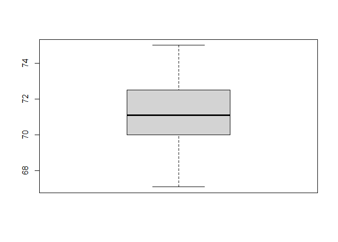

```r
boxplot(y)
```